# p8105_hw1_lz2949

Longyi Zhao

2023-09-17

## Problem 1

```r
# installed the 'moderndive' package in console
# load the 'moderndive' library
library(moderndive)
data("early_january_weather")
```

Variables names of this data are: origin, year, month, day, hour, temp, dewp, humid, wind_dir, wind_speed, wind_gust, precip, pressure, visib, time_hour. There are total 15 variables in the data. The size of this data is characterized by its rows and columns. This data contains 358 rows and 15 columns. Among these variables, temperature has a mean value of 39.58 degrees.

Next step is to make a scatterplot of temperature vs. time hour and describe patterns in this plot.

```r
library(tidyverse)
```

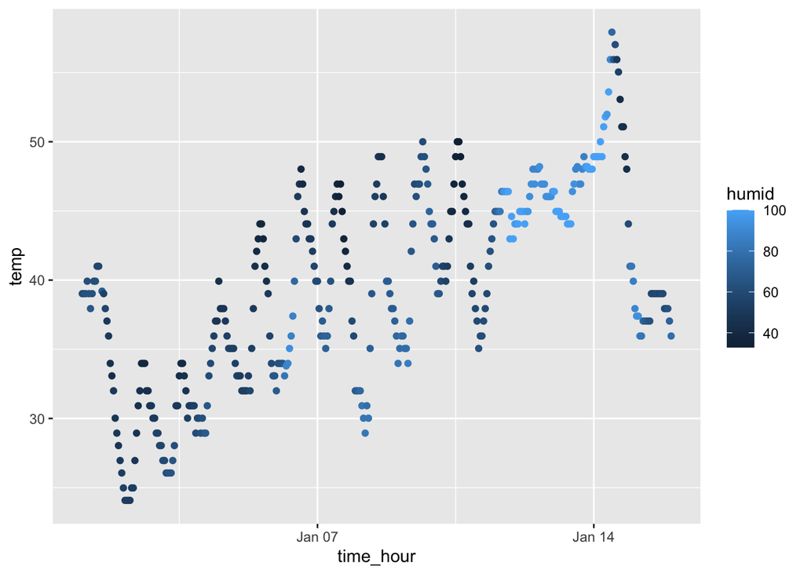

```r
# plot temp vs. time_hour using ggplot
# color points using the humid variable
ggplot(early_january_weather, aes(y=temp,x=time_hour, color=humid))+geom_point()
```

```r
# save the scatterplot using ggsave function
ggsave("scatterplot_hw1_p1.pdf")
```

The temperature fluctuates in the first half of January; the overall trend was increasing. Humidity data show similar trends as the temperature did.

## Problem 2

```r
# create a data frame
# a random sample of size 10 from a standard Normal distribution
dataframe = tibble(
  random_sample = rnorm(10),
  logical_vec = random_sample>0,
  char_vec = c("I","have","a","pet","cat","called","jumy","he","is","black-and-white"),
  vec_factor =factor(c("level1","level2","level3","level1","level2","level3","level1","level2","level3","level3")))

# calculate the mean value of each variable

out_random_sample = pull(dataframe,random_sample)
out_logical_vector = pull(dataframe,logical_vec)
out_character_vector = pull(dataframe,char_vec)
out_factor_vector = pull(dataframe,vec_factor)
```

The mean value of each variable is as follows:

1. Mean value of random sample is 0.5786.
2. Mean value of logical vector is 0.7.
3. Mean value of character vector is NA.
4. Mean value of factor vector is NA.

From the results we can see that means of character vector and factor vector variables cannot be calculated.

```r
# convert variables from one type to another using as.numeric function
l_v = as.numeric(out_logical_vector)
c_v = as.numeric(out_character_vector)
f_v = as.numeric(out_factor_vector)
```

Now, mean value of character vector is NA, mean value of logical vector is 0.7, and mean value of factor vector is 2.1.

In character vector containing non-numeric values, letters cannot be directly converted to numeric values. In factor vector, R would internally assign numbers based on values’ ‘levels’, which is numeric.